# Modeling trends of COVID-19 confirmed cases using linear regression!

2021-04-02

## Data collection and processing

First, we collect the covid-19 data from the website https://raw.githubusercontent.com/CSSEGISandData/COVID-19/master/csse_covid_19_data/csse_covid_19_time_series/time_series_covid19_confirmed_global.csv. And do some data cleaning using R to obtain a cleaned data frame.

```r
library(readr)
library(dplyr)
library(tidyverse)
library(tidyr)
```

```r
confirmedraw <- read.csv("https://raw.githubusercontent.com/CSSEGISandData/COVID-19/master/csse_covid_19_data/csse_covid_19_time_series/time_series_covid19_confirmed_global.csv", head = TRUE,stringsAsFactors = FALSE)

regions <- sort(unique(confirmedraw$Country.Region))
n <- length(regions)
df <- c()
for(i in 1:n) {
  d <- confirmedraw[confirmedraw$Country.Region == regions[i],]
  df <- cbind(df, apply(d[,-c(1:4)], 2, sum))
}
row.names(df) <- 1:nrow(df)
df <- data.frame(df)
colnames(df) <- regions
dates <- seq(as.Date("2020-01-22"),
    as.Date(gsub("X","",colnames(confirmedraw)[ncol(confirmedraw)]),"%m.%d.%y"),1)

df <- mutate(df,
             date = dates,
             total = rowSums(df[,-ncol(df)]))
```

## Data visualizations

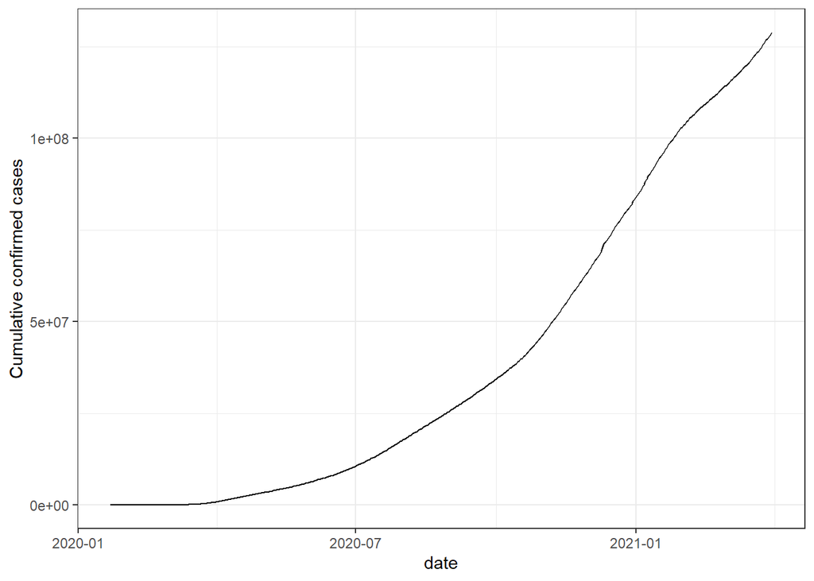

```r
df %>% filter( as.Date("2020-01-22") <= date & date <= as.Date("2021-03-31")) %>%
ggplot(aes(date, total)) + geom_line() + ylab("Cumulative confirmed cases") +
  theme_bw()
```

Figure 1 shows the global trend of covid-19, it can be seen clearly the world faced with serious situation that the confirmed cases of covid-19 is still increasing quickly from the 2020-01 to 2021-03.

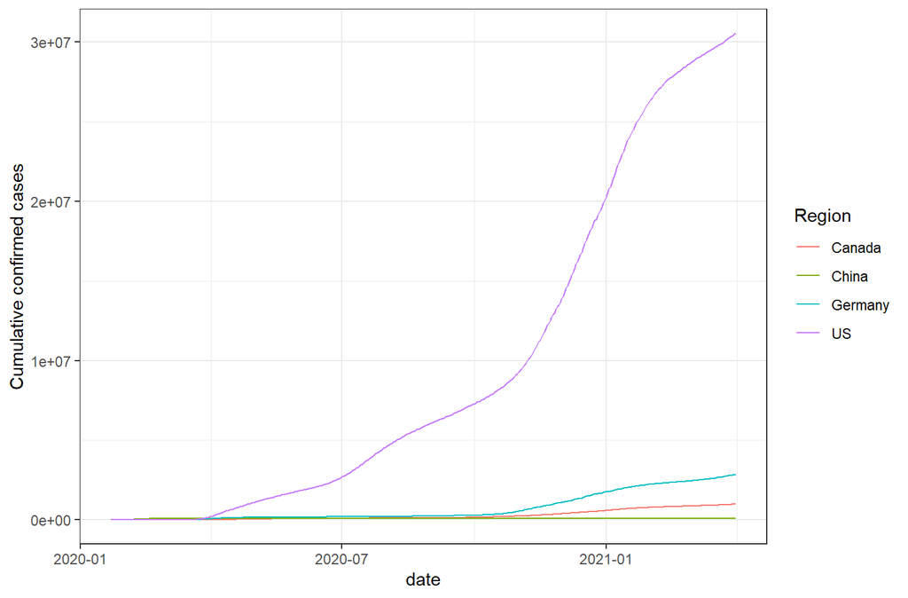

```r
df2 <- df[,c("date","China","US","Canada","Germany")]

df3 <- gather(df2, "Region", "count", -date)

df3 %>% ggplot( aes(date, count, color = Region))  + geom_line() +
     ylab("Cumulative confirmed cases") +
     theme_bw()
```

Figure 2 shows the trends of covid-19 in the 4 countres “China”,“US”,“Canada”,“Germany” respecitvely, clearly, it can be seen the cases in US are most and situation is worst that the increasing speed and cases are both highest. For China, the line is almost horizonal now while the countries Canada and Germany are in the middle.

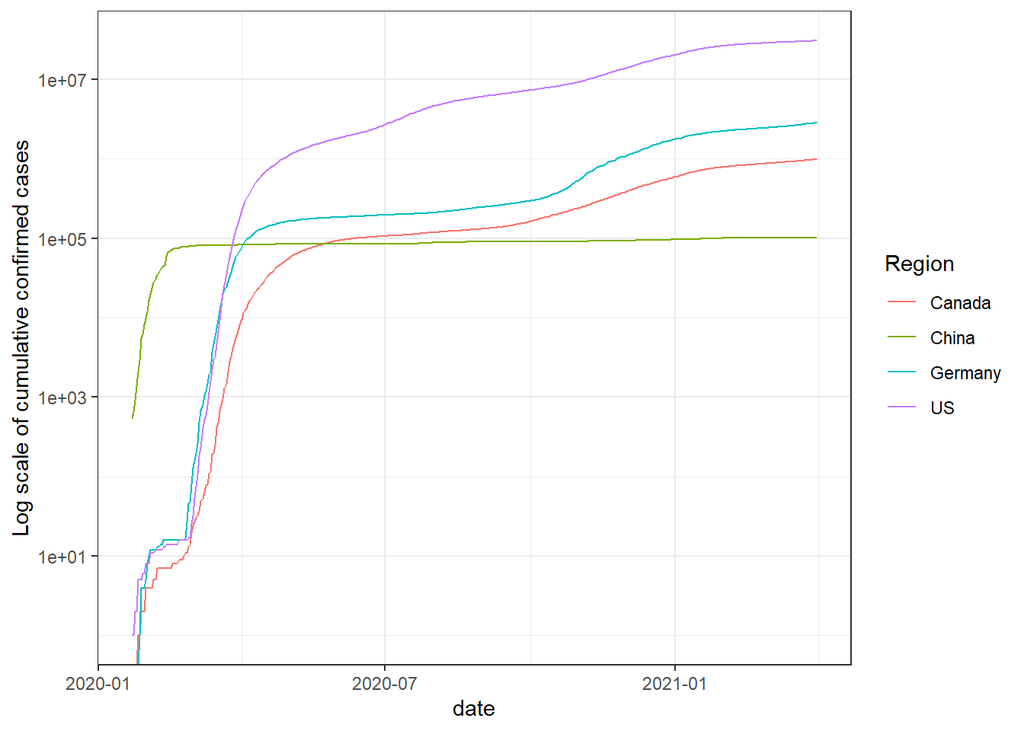

```r
df3 %>% ggplot( aes(date, count, color = Region))  + geom_line() +
     ylab("Log scale of cumulative confirmed cases") +
     theme_bw() + scale_y_log10()
```

Figure 3 shows the trends of covid-19 in log scales for the above 4 countries, clearly, it shows the speed of the increasing of new confirmed cases, that China has almost with a speed 0 compared the other 3 countries, it indicates the convid-19 in China is controlled very well but in other countries, the situations are very seriously.

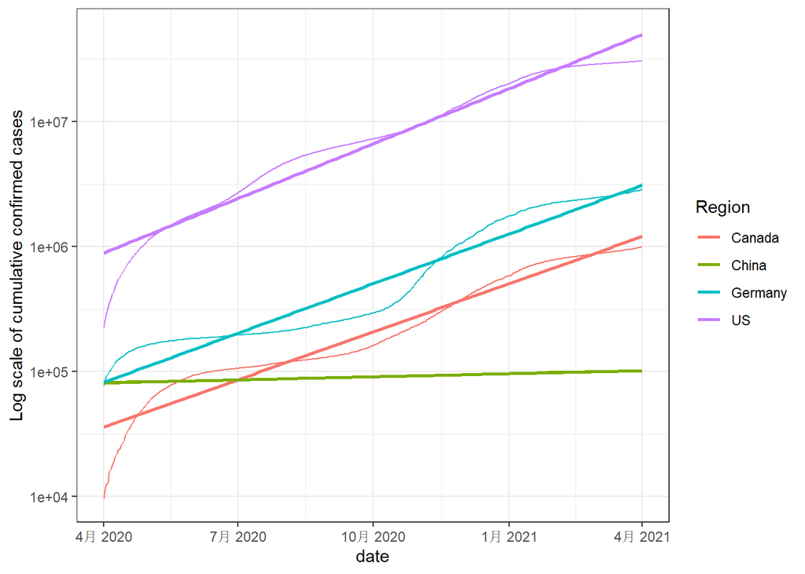

```r
df3 %>% filter(as.Date("2020-04-01") <= date) %>%
  ggplot( aes(date, count, color = Region))  + geom_line() +
     ylab("Log scale of cumulative confirmed cases") +
     theme_bw() + scale_y_log10() +  geom_smooth(method = "lm", fill = NA)
```